# F1 Braking System Analysis

This document details how preliminary preformances of a **F1 vehicle braking system** can be defined, starting from a set of assumption.

## Problem description

It is necessary to define which are the performances required from a braking system in order to proceed with the design of the equipment. The braking system must guarantee the best braking performance, i.e., the braking system must not be the limiting factor. This means that the braking system must be able to bring the vehicle to the limits of its braking performance.

The performance to be defined are:

- Maximum braking torques ($T_f$, $T_r$),
- Single braking energy ($E_f$, $E_r$),
- Thermal power dissipation ($\dot{Q}_f$, $\dot{Q}_r$).

Consider the following diagram:

[figure not shown]

By definition, the braking limit is given by the maximum *friction coefficient* ($\mu$) between tyre and road, and the maximum *braking force* ($X_f$, $X_r$) is function of the vertical load on the tyre ($Z_f$, $Z_r$) (thus considering an theoretically optimal brake balance set-up):

$$\operatorname{X_{f}}{\left (v{\left (t \right )} \right )} = \mu \operatorname{Z_{f}}{\left (v{\left (t \right )} \right )}$$

$$\operatorname{X_{r}}{\left (v{\left (t \right )} \right )} = \mu \operatorname{Z_{r}}{\left (v{\left (t \right )} \right )}$$

**Warning:** the above relations hold **only** for $v>0$. When integrating any differential equation over time, care must be taken to consider only positive speed, in order to avoid any erroneous result.

The dynamic equilibrium (horizontal, vertical and rotational at the center of mass) gives:

$$m a{\left (t \right )} = - \operatorname{F_{d}}{\left (v{\left (t \right )} \right )} - \operatorname{X_{f}}{\left (v{\left (t \right )} \right )} - \operatorname{X_{r}}{\left (v{\left (t \right )} \right )}$$

$$g m + \operatorname{F_{lf}}{\left (v{\left (t \right )} \right )} + \operatorname{F_{lr}}{\left (v{\left (t \right )} \right )} = \operatorname{Z_{f}}{\left (v{\left (t \right )} \right )} + \operatorname{Z_{r}}{\left (v{\left (t \right )} \right )}$$

$$\alpha l \operatorname{Z_{f}}{\left (v{\left (t \right )} \right )} + l \left(- \alpha + 1\right) \operatorname{F_{lr}}{\left (v{\left (t \right )} \right )} + \left(- h + h_{cp}\right) \operatorname{F_{d}}{\left (v{\left (t \right )} \right )} = \alpha l \operatorname{F_{lf}}{\left (v{\left (t \right )} \right )} + h \left(\operatorname{X_{f}}{\left (v{\left (t \right )} \right )} + \operatorname{X_{r}}{\left (v{\left (t \right )} \right )}\right) + l \left(- \alpha + 1\right) \operatorname{Z_{r}}{\left (v{\left (t \right )} \right )}$$

where: $$ \alpha = \frac{l_f}{l} = \frac{l_f}{l_f + l_r} $$

Once the braking forces are known, single-corner braking torques $T_f$ and $T_r$ can be obtained with:

$$\operatorname{T_{f}}{\left (v{\left (t \right )} \right )} = 0.5 r_{f} \operatorname{X_{f}}{\left (v{\left (t \right )} \right )}$$

$$\operatorname{T_{r}}{\left (v{\left (t \right )} \right )} = 0.5 r_{r} \operatorname{X_{r}}{\left (v{\left (t \right )} \right )}$$

The single-corner cumulated braking energies $E_f(\tau)$ and $E_r(\tau)$ can be computed as:

$$\operatorname{E_{f}}{\left (\tau \right )} = \int_{0}^{\tau} \operatorname{P_{f}}{\left (v{\left (t \right )} \right )}\, dt$$

$$\operatorname{E_{r}}{\left (\tau \right )} = \int_{0}^{\tau} \operatorname{P_{r}}{\left (v{\left (t \right )} \right )}\, dt$$

where single-corner braking powers $P_f$ and $P_r$ are defined as:

$$\operatorname{P_{f}}{\left (v{\left (t \right )} \right )} = 0.5 \operatorname{X_{f}}{\left (v{\left (t \right )} \right )} v{\left (t \right )}$$

$$\operatorname{P_{r}}{\left (v{\left (t \right )} \right )} = 0.5 \operatorname{X_{r}}{\left (v{\left (t \right )} \right )} v{\left (t \right )}$$

and the corresponding total braking energies $E_{f}^{tot}$ and $E_{r}^{tot}$:

$$E^{tot}_{f} = \operatorname{E_{f}}{\left (t_{end} \right )}$$

$$E^{tot}_{r} = \operatorname{E_{r}}{\left (t_{end} \right )}$$

where $t_{end}$ is the time at which the final braking speed $v_{end}$ is reached:

$$v{\left (t_{end} \right )} = v_{end}$$

In order to prevent overheating, the braking system should be able to thermally dissipate the energy stored during the braking events. Once the braking system reaches its thermal working point, it should be able to completely dissipate the braking energy over a complete lap, i.e., the system should be able to return to the nominal working temperature.

Since every racing circuit is different and the number and intensity of braking events over a complete lap is difficult to define precisely, the thermal dissipation required $\dot{Q}$ will be estimated as a percentual increase from the last championship, considering the analogous braking energy increase $\Delta E_b$:

$$\Delta\dot{Q}_f = \Delta E_f^{tot}$$

$$\Delta\dot{Q}_r = \Delta E_r^{tot}$$

$$\Delta\dot{Q}_f = \frac{\dot{Q}_f - \left.\dot{Q}_f\right|_{past}}{\left.\dot{Q}_f\right|_{past}}$$

$$\Delta\dot{Q}_r = \frac{\dot{Q}_r - \left.\dot{Q}_r\right|_{past}}{\left.\dot{Q}_r\right|_{past}}$$

$$\Delta E_f^{tot} = \frac{E^{tot}_{f} - \left.E_f^{tot}\right|_{past}}{\left.E_f^{tot}\right|_{past}}$$

$$\Delta E_r^{tot} = \frac{E^{tot}_{r} - \left.E_r^{tot}\right|_{past}}{\left.E_r^{tot}\right|_{past}}$$

## Analytical Solution

Solving the system of equations for $a$, $X_f$, $X_r$, $Z_f$ and $Z_r$:

$$a{\left (t \right )} = - \frac{g m \mu + \mu \operatorname{F_{lf}}{\left (v{\left (t \right )} \right )} + \mu \operatorname{F_{lr}}{\left (v{\left (t \right )} \right )} + \operatorname{F_{d}}{\left (v{\left (t \right )} \right )}}{m}$$

$$\operatorname{X_{f}}{\left (v{\left (t \right )} \right )} = \frac{\mu \left(- \alpha g l m + g h m \mu + g l m + h \mu \operatorname{F_{lf}}{\left (v{\left (t \right )} \right )} + h \mu \operatorname{F_{lr}}{\left (v{\left (t \right )} \right )} + h \operatorname{F_{d}}{\left (v{\left (t \right )} \right )} - h_{cp} \operatorname{F_{d}}{\left (v{\left (t \right )} \right )} + l \operatorname{F_{lf}}{\left (v{\left (t \right )} \right )}\right)}{l}$$

$$\operatorname{X_{r}}{\left (v{\left (t \right )} \right )} = - \frac{\mu \left(- \alpha g l m + g h m \mu + h \mu \operatorname{F_{lf}}{\left (v{\left (t \right )} \right )} + h \mu \operatorname{F_{lr}}{\left (v{\left (t \right )} \right )} + h \operatorname{F_{d}}{\left (v{\left (t \right )} \right )} - h_{cp} \operatorname{F_{d}}{\left (v{\left (t \right )} \right )} - l \operatorname{F_{lr}}{\left (v{\left (t \right )} \right )}\right)}{l}$$

$$\operatorname{Z_{f}}{\left (v{\left (t \right )} \right )} = \frac{- \alpha g l m + g h m \mu + g l m + h \mu \operatorname{F_{lf}}{\left (v{\left (t \right )} \right )} + h \mu \operatorname{F_{lr}}{\left (v{\left (t \right )} \right )} + h \operatorname{F_{d}}{\left (v{\left (t \right )} \right )} - h_{cp} \operatorname{F_{d}}{\left (v{\left (t \right )} \right )} + l \operatorname{F_{lf}}{\left (v{\left (t \right )} \right )}}{l}$$

$$\operatorname{Z_{r}}{\left (v{\left (t \right )} \right )} = \frac{\alpha g l m - g h m \mu - h \mu \operatorname{F_{lf}}{\left (v{\left (t \right )} \right )} - h \mu \operatorname{F_{lr}}{\left (v{\left (t \right )} \right )} - h \operatorname{F_{d}}{\left (v{\left (t \right )} \right )} + h_{cp} \operatorname{F_{d}}{\left (v{\left (t \right )} \right )} + l \operatorname{F_{lr}}{\left (v{\left (t \right )} \right )}}{l}$$

The above equations are expressed in terms of physical characteristics of the vehicle ($\mu$, $m$, $h$, $h_{cp}$, $l$, and $\alpha$), as well as aerodynamic forces ($F_{lf}$, $F_{lr}$, $F_d$).  
Aerodynamic forces are defined as:

$$\operatorname{F_{lf}}{\left (v{\left (t \right )} \right )} = S \operatorname{C_{lf}}{\left (v{\left (t \right )} \right )} q{\left (v{\left (t \right )} \right )}$$

$$\operatorname{F_{lr}}{\left (v{\left (t \right )} \right )} = S \operatorname{C_{lr}}{\left (v{\left (t \right )} \right )} q{\left (v{\left (t \right )} \right )}$$

$$\operatorname{F_{d}}{\left (v{\left (t \right )} \right )} = C_{d} S q{\left (v{\left (t \right )} \right )}$$

where $S$ is the vehicle front area, $C_{lf}$, $C_{lr}$ and $C_d$ are the aerodynamic coefficients and $q$ is the dynamic pressure, defined as:

$$q{\left (v{\left (t \right )} \right )} = 0.5 \rho v^{2}{\left (t \right )}$$

The variation of lift's distribution on front and rear axle with the speed is taken into account introducing the *aerobalance* term ($A_b$), defined as:

$$\operatorname{A_{b}}{\left (v{\left (t \right )} \right )} = k_{1} v^{2}{\left (t \right )} + k_{2} v{\left (t \right )} + k_{3}$$

from which the front and rear lift coefficients can be obtained once the overall lift coefficient ($C_l$) is known:

$$\operatorname{C_{lf}}{\left (v{\left (t \right )} \right )} = C_{l} \operatorname{A_{b}}{\left (v{\left (t \right )} \right )}$$

$$\operatorname{C_{lr}}{\left (v{\left (t \right )} \right )} = C_{l} \left(- \operatorname{A_{b}}{\left (v{\left (t \right )} \right )} + 1\right)$$

Substituting the aerodynamic forces within the previous solution yields the explicit functions for $a(v(t))$, $X_f(v(t))$, $X_r(v(t))$, $Z_f(v(t))$ and $Z_r(v(t))$.

It is also possible to obtain the analytical forms of the braking torques $T_f(v(t))$, $T_r(v(t))$ and braking energies $E_r(v(t))$, $E_f(v(t))$.

All these solutions are expressed as functions of the vehicle speed $v(t)$, that can be analytically determined by integrating the first equation:

$$\frac{d}{d t} v{\left (t \right )} = - g \mu + \left(- \frac{0.5 C_{d} S \rho}{m} - \frac{0.5 C_{l} S \mu \rho}{m}\right) v^{2}{\left (t \right )}$$

That is in the form:

$$A v^{2}{\left (t \right )} + B + \frac{d}{d t} v{\left (t \right )} = 0$$

$$\left \{ A : \frac{0.5 S \rho \left(C_{d} + C_{l} \mu\right)}{m}, \quad B : g \mu\right \}$$

The general solution of this differential equation is:

$$v{\left (t \right )} = \frac{\sqrt{B} \tan{\left (\sqrt{A} \sqrt{B} \left(C_{1} - t\right) \right )}}{\sqrt{A}}$$

The speed function is in the form:

$$v{\left (t \right )} = \Gamma \tan{\left (\Delta \left(E - t\right) \right )}$$

$$\left \{ \Delta : \sqrt{A} \sqrt{B}, \quad \Gamma : \frac{\sqrt{B}}{\sqrt{A}}\right \}$$

Given an initial speed $v(0) = v_0$, it is possible to evaluate the exact solution:

$$\left \{ E : \frac{\operatorname{atan}{\left (\frac{v_{0}}{\Gamma} \right )}}{\Delta}\right \}$$

$$v{\left (t \right )} = - \Gamma \tan{\left (\Delta t - \operatorname{atan}{\left (\frac{v_{0}}{\Gamma} \right )} \right )}$$

The function above can be used to determine the analytical functions of the braking torques $T_f(t)$ and $T_r(t)$ as well as the value for $t_{end}$.

Regarding the braking energies $E_f$ and $E_r$, a definite integration must be performed:

$$\operatorname{E_{f}}{\left (\tau \right )} = \int_{0}^{\tau} \left(0.25 C_{l} S k_{1} \mu \rho v^{5}{\left (t \right )} + 0.25 C_{l} S k_{2} \mu \rho v^{4}{\left (t \right )} + \left(- 0.5 \alpha g m \mu + \frac{0.5 g h m \mu^{2}}{l} + 0.5 g m \mu\right) v{\left (t \right )} + \left(\frac{0.25 C_{d} S h \mu \rho}{l} - \frac{0.25 C_{d} S h_{cp} \mu \rho}{l} + \frac{0.25 C_{l} S h \mu^{2} \rho}{l} + 0.25 C_{l} S k_{3} \mu \rho\right) v^{3}{\left (t \right )}\right)\, dt$$

$$\operatorname{E_{r}}{\left (\tau \right )} = \int_{0}^{\tau} \left(- 0.25 C_{l} S k_{1} \mu \rho v^{5}{\left (t \right )} - 0.25 C_{l} S k_{2} \mu \rho v^{4}{\left (t \right )} + \left(0.5 \alpha g m \mu - \frac{0.5 g h m \mu^{2}}{l}\right) v{\left (t \right )} + \left(- \frac{0.25 C_{d} S h \mu \rho}{l} + \frac{0.25 C_{d} S h_{cp} \mu \rho}{l} - \frac{0.25 C_{l} S h \mu^{2} \rho}{l} - 0.25 C_{l} S k_{3} \mu \rho + 0.25 C_{l} S \mu \rho\right) v^{3}{\left (t \right )}\right)\, dt$$

Both integrals are in the form:

$$\operatorname{E_{b}}{\left (\tau \right )} = \int_{0}^{\tau} \left(C_{1} v{\left (t \right )} + C_{2} v^{3}{\left (t \right )} + C_{3} v^{4}{\left (t \right )} + C_{4} v^{5}{\left (t \right )}\right)\, dt$$

$$\left \{ C_{1} : - 0.5 \alpha g m \mu + \frac{0.5 g h m \mu^{2}}{l} + 0.5 g m \mu, \quad C_{2} : \frac{0.25 C_{d} S h \mu \rho}{l} - \frac{0.25 C_{d} S h_{cp} \mu \rho}{l} + \frac{0.25 C_{l} S h \mu^{2} \rho}{l} + 0.25 C_{l} S k_{3} \mu \rho, \quad C_{3} : 0.25 C_{l} S k_{2} \mu \rho, \quad C_{4} : 0.25 C_{l} S k_{1} \mu \rho\right \}$$

$$\left \{ C_{1} : 0.5 \alpha g m \mu - \frac{0.5 g h m \mu^{2}}{l}, \quad C_{2} : - \frac{0.25 C_{d} S h \mu \rho}{l} + \frac{0.25 C_{d} S h_{cp} \mu \rho}{l} - \frac{0.25 C_{l} S h \mu^{2} \rho}{l} - 0.25 C_{l} S k_{3} \mu \rho + 0.25 C_{l} S \mu \rho, \quad C_{3} : - 0.25 C_{l} S k_{2} \mu \rho, \quad C_{4} : - 0.25 C_{l} S k_{1} \mu \rho\right \}$$

where $v(t)$ is:

$$v{\left (t \right )} = \Gamma \tan{\left (\Delta \left(E - t\right) \right )}$$

$$\left \{ E : \frac{\operatorname{atan}{\left (\frac{v_{0}}{\Gamma} \right )}}{\Delta}\right \}$$

$$\left \{ \Delta : \sqrt{A} \sqrt{B}, \quad \Gamma : \frac{\sqrt{B}}{\sqrt{A}}\right \}$$

$$\left \{ A : \frac{0.5 S \rho \left(C_{d} + C_{l} \mu\right)}{m}, \quad B : g \mu\right \}$$

Substituting the speed equation:

$$\operatorname{E_{b}}{\left (\tau \right )} = \int_{0}^{\tau} C_{1} \Gamma \tan{\left (\Delta E - \Delta t \right )}\, dt + \int_{0}^{\tau} C_{2} \Gamma^{3} \tan^{3}{\left (\Delta E - \Delta t \right )}\, dt + \int_{0}^{\tau} C_{3} \Gamma^{4} \tan^{4}{\left (\Delta E - \Delta t \right )}\, dt + \int_{0}^{\tau} C_{4} \Gamma^{5} \tan^{5}{\left (\Delta E - \Delta t \right )}\, dt$$

Solving the integrals yields:

$$\operatorname{E_{b}}{\left (\tau \right )} = \frac{C_{1} \Gamma \log{\left (\tan^{2}{\left (\Delta E \right )} + 1 \right )}}{2 \Delta} - \frac{C_{1} \Gamma \log{\left (\tan^{2}{\left (\Delta E - \Delta \tau \right )} + 1 \right )}}{2 \Delta} - C_{2} \Gamma^{3} \left(\frac{\log{\left (\tan^{2}{\left (\Delta E \right )} + 1 \right )}}{2 \Delta} - \frac{\tan^{2}{\left (\Delta E \right )}}{2 \Delta}\right) + C_{2} \Gamma^{3} \left(\frac{\log{\left (\tan^{2}{\left (\Delta E - \Delta \tau \right )} + 1 \right )}}{2 \Delta} - \frac{\tan^{2}{\left (\Delta E - \Delta \tau \right )}}{2 \Delta}\right) - C_{3} \Gamma^{4} \left(- \frac{\tan^{3}{\left (\Delta E \right )}}{3 \Delta} + \frac{\tan{\left (\Delta E \right )}}{\Delta}\right) + C_{3} \Gamma^{4} \left(\tau - \frac{\tan^{3}{\left (\Delta E - \Delta \tau \right )}}{3 \Delta} + \frac{\tan{\left (\Delta E - \Delta \tau \right )}}{\Delta}\right) - C_{4} \Gamma^{5} \left(- \frac{\log{\left (\tan^{2}{\left (\Delta E \right )} + 1 \right )}}{2 \Delta} - \frac{\tan^{4}{\left (\Delta E \right )}}{4 \Delta} + \frac{\tan^{2}{\left (\Delta E \right )}}{2 \Delta}\right) + C_{4} \Gamma^{5} \left(- \frac{\log{\left (\tan^{2}{\left (\Delta E - \Delta \tau \right )} + 1 \right )}}{2 \Delta} - \frac{\tan^{4}{\left (\Delta E - \Delta \tau \right )}}{4 \Delta} + \frac{\tan^{2}{\left (\Delta E - \Delta \tau \right )}}{2 \Delta}\right)$$

Substituting back $A$, $B$, $\Gamma$, $\Delta$, $E$, $C_1$, $C_2$, $C_3$ and $C_4$ yields the parametric expression for the braking energy $E_b(\tau)$.

# Numerical Evaluation

It is now possible to define a few values for the physical quantities:

$$\left \{ g : \frac{9.80665 meter}{second^{2}}, \quad \rho : \frac{1.225 kilogram}{meter^{3}}, \quad t : t second, \quad \tau : \tau second\right \}$$

$$\left \{ C_{d} : 0.75, \quad C_{l} : 2.98, \quad S : 1.42 meter^{2}, \quad \alpha : 0.48, \quad h : 0.265 meter, \quad h_{cp} : 0.265 meter, \quad k_{1} : 0, \quad k_{2} : 0, \quad k_{3} : 0.42, \quad l : 3.25 meter, \quad m : 933 kilogram, \quad \mu : 1.3, \quad r_{f} : 0.35 meter, \quad r_{r} : 0.35 meter\right \}$$

$$\left \{ t_{0} : 0, \quad t_{diss} : 5 second, \quad v_{0} : \frac{95 meter}{second}, \quad v_{end} : \frac{125 meter}{6 second}\right \}$$

Substituting within the speed function yields:

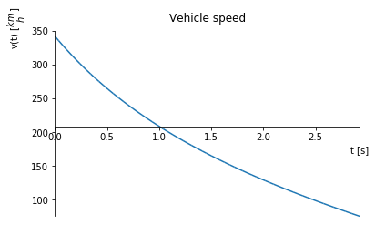

$$t_{end} = 2.922 second$$

Once the speed function it is know, the front and rear braking torques can be obtained:

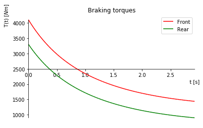

$$\operatorname{T_{f}}{\left (0 \right )} = 4102.0 meter newton$$

$$\operatorname{T_{r}}{\left (0 \right )} = 3301.0 meter newton$$

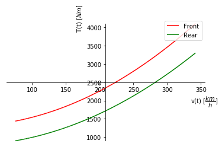

The above values for the torques are very conservative, since it is sperimentally observed that the pilot is not able to reach the braking limit istantaneously. Typically, the braking limit is reached within a few tenths of second, and this reduces the maximum torque that the braking system must be able to provide:

$$\operatorname{T_{f}}{\left (0.1 second \right )} = 3817.0 meter newton$$

$$\operatorname{T_{r}}{\left (0.1 second \right )} = 3044.0 meter newton$$

The corresponding braking energies are:

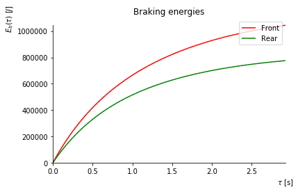

$$E^{tot}_{f} = 1.044 \cdot 10^{6} joule$$

$$E^{tot}_{r} = 7.756 \cdot 10^{5} joule$$

and the thermal power dissipation:

$$\Delta\dot{Q}_f = \Delta E_f^{tot} = 14.0 percent$$

$$\Delta\dot{Q}_r = \Delta E_r^{tot} = 19.0 percent$$